# 09-mlr

Professor Shannon Ellis

2023-10-31

# Multiple Linear Regression

## Q&A

> Q: What are some ways we can make our visuals accessible? For example, how can we account for color blind people when incorporating graphs and figures in our presentation?  
> A: Love this question! One way to do this is to use tools built for just this purpose! For example, for color blindness, [ColorBrewer2](https://colorbrewer2.org/) allows you to toggle for color palletes that are “colorblind safe.” Similarly, for written content online, ensuring that you’re including alt-text for all images, to enable visual understanding by those with vision impariments/differences. For those with learning differences (i.e. dyslexia, ADHD), I’m *sure* there’s research out there with respect to viz, and I should make myself more familiar, but ensuring that you’re not using very similar acronyms/initialisms for different context or using consistent icons (Rather than letters) across visualizations, etc. can really help individuals with learning differences and overall make your viz more consistent/understandable. This is just the tip of the iceberg. Additional suggestions [here](https://www.highcharts.com/blog/tutorials/10-guidelines-for-dataviz-accessibility/).

## Course Announcements

- 🎃 Happy Halloween!
  - No OH today after class
  - Make up: tomorrow 10-11AM (CSB 243)
- 🔬 There is NO lab to turn in this week
  - Lab will be used for midterm review
  - Come to lab with questions!
- 🏫 Midterm is due next Monday at 11:59PM
  - will be released 5PM Friday
  - completed individually
  - open notes/open Internet
  - NOT timed
  - typically takes students ~2.5h to complete (big range: 2-15h)
- Lab05 & HW03 will be released next Monday

## Suggested Reading

Introduction to Modern Statistics Chapter 8: [Linear Regression with Multiple Predictors](https://openintro-ims.netlify.app/model-mlr.html)

## Agenda

- Multiple Linear Regression
  - Multiple predictors
  - Main vs interaction effects
  - Model comparison
  - Backward selection

## Packages & Data

```r
library(tidyverse)
library(tidymodels)
```

**Data: Paris Paintings**

```r
pp <- read_csv("https://raw.githubusercontent.com/COGS137/datasets/main/paris_paintings.csv",
               na = c("n/a", "", "NA")) |>
  mutate(log_price = log(price))
```

- Number of observations: 3393
- Number of variables: 62

# Two numerical predictors

## Multiple predictors

- Response variable: `log_price`
- Explanatory variables: Width and height

```r
lin_mod <- linear_reg() |>
  set_engine("lm")

pp_fit <- lin_mod |>
  fit(log_price ~ Width_in + Height_in, data = pp)
tidy(pp_fit)
```

```
# A tibble: 3 × 5
  term        estimate std.error statistic  p.value
  <chr>          <dbl>     <dbl>     <dbl>    <dbl>
1 (Intercept)   4.77     0.0579      82.4  0
2 Width_in      0.0269   0.00373      7.22 6.58e-13
3 Height_in    -0.0133   0.00395     -3.36 7.93e- 4
```

## Linear model with multiple predictors

```
# A tibble: 3 × 5
  term        estimate std.error statistic  p.value
  <chr>          <dbl>     <dbl>     <dbl>    <dbl>
1 (Intercept)   4.77     0.0579      82.4  0
2 Width_in      0.0269   0.00373      7.22 6.58e-13
3 Height_in    -0.0133   0.00395     -3.36 7.93e- 4
```

$$\widehat{log\_price} = 4.77 + 0.0269 \times width - 0.0133 \times height$$

❓ How do we interpret this model?

# Numerical and categorical predictors

## Price, surface area, and living artist

- Explore the relationship between price of paintings and surface area, conditioned on whether or not the artist is still living
- First visualize and explore, then model
- But first, prep the data:

```r
pp <- pp |>
  mutate(artistliving = case_when(artistliving == 0 ~ "Deceased",
                                  TRUE ~ "Living"))

pp |>
  count(artistliving)
```

```
# A tibble: 2 × 2
  artistliving     n
  <chr>        <int>
1 Deceased      2937
2 Living         456
```

## Typical surface area

- Plot
- Code

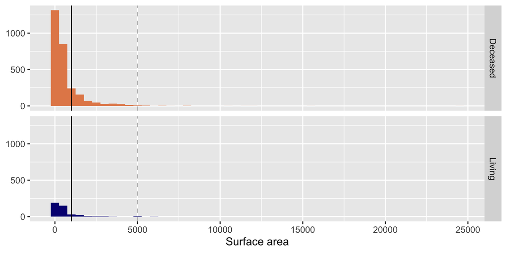

Typical surface area appears to be less than 1000 square inches (~ 80cm x 80cm). There are very few paintings that have surface area above 5000 square inches.

```r
ggplot(data = pp, aes(x = Surface, fill = artistliving)) +
  geom_histogram(binwidth = 500) +
  facet_grid(artistliving ~ .) +
  scale_fill_manual(values = c("#E48957", "#071381")) +
  guides(fill = "none") +
  labs(x = "Surface area", y = NULL) +
  geom_vline(xintercept = 1000) +
  geom_vline(xintercept = 5000, linetype = "dashed", color = "gray")
```

## Narrowing the scope

- Plot
- Code

For simplicity let’s focus on the paintings with `Surface < 5000`:

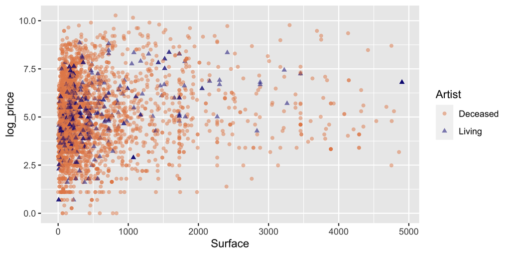

```r
pp_Surf_lt_5000 <- pp |>
  filter(Surface < 5000)

ggplot(data = pp_Surf_lt_5000,
       aes(y = log_price, x = Surface, color = artistliving, shape = artistliving)) +
  geom_point(alpha = 0.5) +
  labs(color = "Artist", shape = "Artist") +
  scale_color_manual(values = c("#E48957", "#071381"))
```

## Facet to get a better look

- Plot
- Code

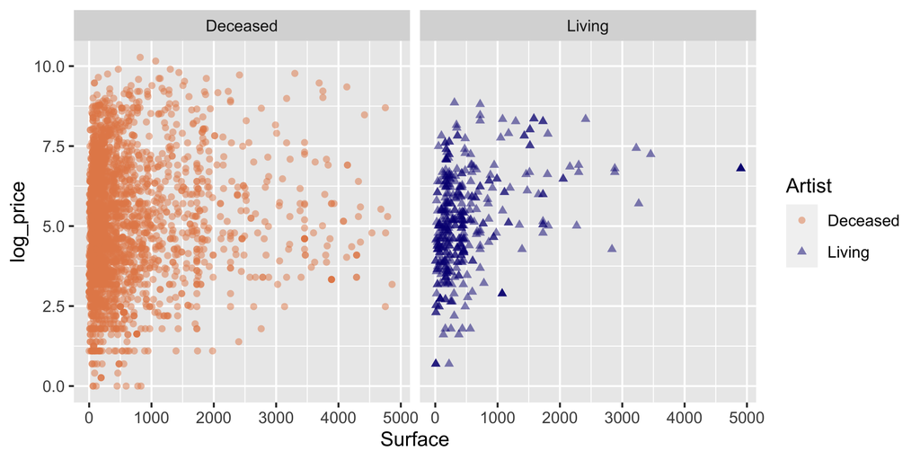

```r
ggplot(data = pp_Surf_lt_5000,
       aes(y = log_price, x = Surface, color = artistliving, shape = artistliving)) +
  geom_point(alpha = 0.5) +
  facet_wrap(~artistliving) +
  scale_color_manual(values = c("#E48957", "#071381")) +
  labs(color = "Artist", shape = "Artist")
```

## Two ways to model

- **Main effects:** Assuming relationship between surface and logged price **does not vary** by whether or not the artist is living.
- **Interaction effects:** Assuming relationship between surface and logged price **varies** by whether or not the artist is living.

## Interacting explanatory variables

- Including an interaction effect in the model allows for different slopes, i.e. nonparallel lines.
- This implies that the regression coefficient for an explanatory variable would change as another explanatory variable changes.
- This can be accomplished by adding an interaction variable: the product of two explanatory variables.

## Two ways to model

- **Main effects:** Assuming relationship between surface and logged price **does not vary** by whether or not the artist is living
- **Interaction effects:** Assuming relationship between surface and logged price **varies** by whether or not the artist is living

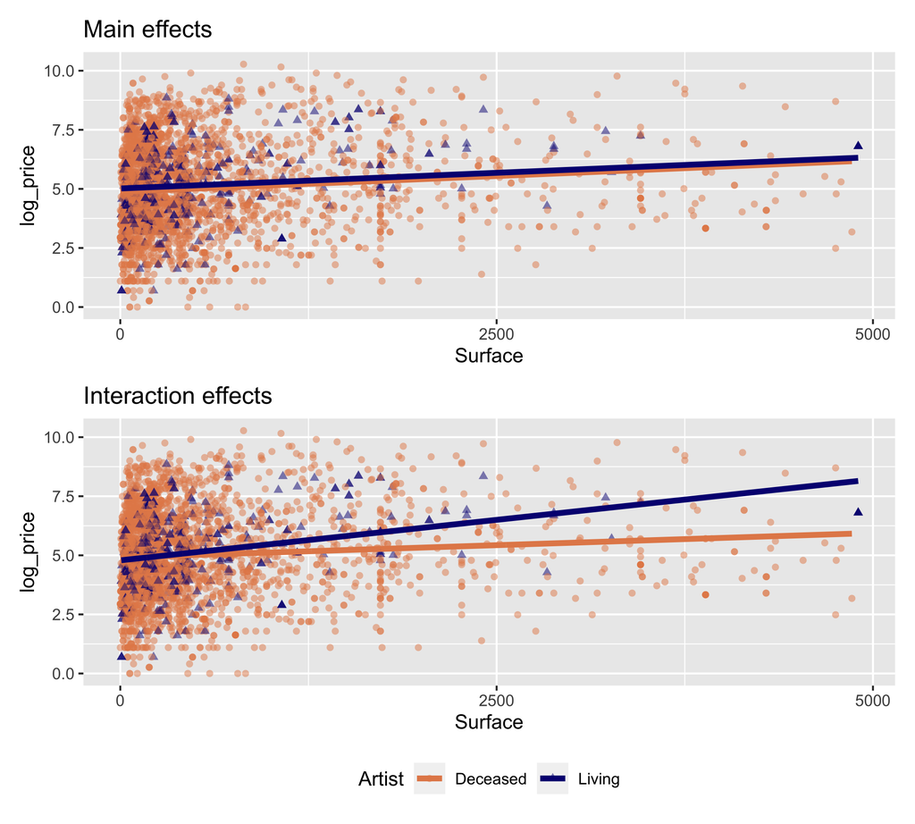

❓ Which does your intuition/knowledge of the data suggest is more appropriate?

Put a green sticky if you think main; pink if you think interaction.

## Fit model with main effects

- Response variable: `log_price`
- Explanatory variables: `Surface` area and `artistliving`

```r
pp_main_fit <- lin_mod |>
  fit(log_price ~ Surface + artistliving, data = pp_Surf_lt_5000)
tidy(pp_main_fit)
```

```
# A tibble: 3 × 5
  term               estimate std.error statistic  p.value
  <chr>                 <dbl>     <dbl>     <dbl>    <dbl>
1 (Intercept)        4.88     0.0424       115.   0
2 Surface            0.000265 0.0000415      6.39 1.85e-10
3 artistlivingLiving 0.137    0.0970         1.41 1.57e- 1
```

$$\widehat{log\_price} = 4.88 + 0.000265 \times surface + 0.137 \times artistliving$$

## Solving the model

- Non-living artist: Plug in 0 for `artistliving`

$\widehat{log\_price} = 4.88 + 0.000265 \times surface + 0.137 \times 0$  
$= 4.88 + 0.000265 \times surface$

- Living artist: Plug in 1 for `artistliving`

$\widehat{log\_price} = 4.88 + 0.000265 \times surface + 0.137 \times 1$  
$= 5.017 + 0.000265 \times surface$

## Visualizing main effects

- **Same slope:** Rate of change in price as the surface area increases does not vary between paintings by living and non-living artists.
- **Different intercept:** Paintings by living artists are consistently more expensive than paintings by non-living artists.

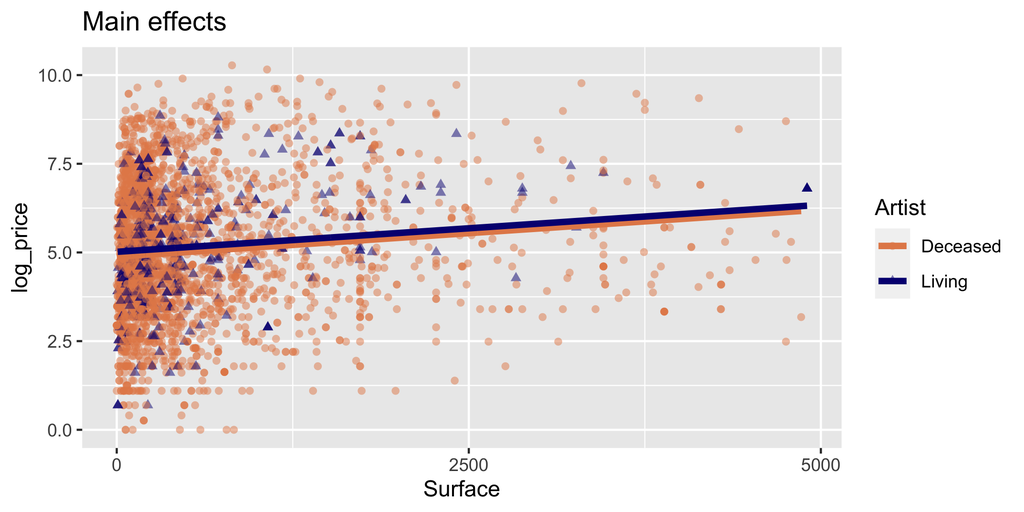

## Interpreting main effects

```r
tidy(pp_main_fit) |>
  mutate(exp_estimate = exp(estimate)) |>
  select(term, estimate, exp_estimate)
```

```
# A tibble: 3 × 3
  term               estimate exp_estimate
  <chr>                 <dbl>        <dbl>
1 (Intercept)        4.88           132.
2 Surface            0.000265         1.00
3 artistlivingLiving 0.137            1.15
```

- All else held constant, for each additional square inch in painting’s surface area, the price of the painting is predicted, on average, to be higher by a factor of 1.
- All else held constant, paintings by a living artist are predicted, on average, to be higher by a factor of 1.15 compared to paintings by an artist who is no longer alive.
- Paintings that are by an artist who is not alive and that have a surface area of 0 square inches are predicted, on average, to be 132 livres.

## Main vs. interaction effects

- The way we specified our main effects model only lets `artistliving` affect the intercept.
- Model implicitly assumes that paintings with living and deceased artists have the *same slope* and only allows for *different intercepts*.

❓ What seems more appropriate in this case?

- Same slope and same intercept for both colors
- Same slope and different intercept for both colors
- Different slope and different intercept for both colors

## Interaction: `Surface * artistliving`

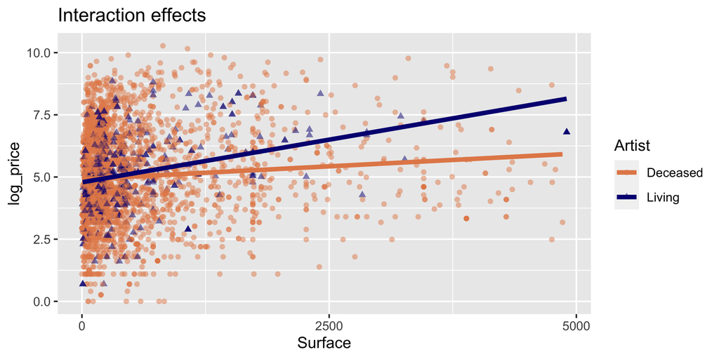

## Fit model with interaction effects

- Response variable: `log_price`
- Explanatory variables: `Surface` area, `artistliving`, and their interaction

```r
pp_int_fit <- lin_mod |>
  fit(log_price ~ Surface * artistliving, data = pp_Surf_lt_5000)
tidy(pp_int_fit)
```

```
# A tibble: 4 × 5
  term                        estimate std.error statistic    p.value
  <chr>                          <dbl>     <dbl>     <dbl>      <dbl>
1 (Intercept)                 4.91     0.0432       114.   0
2 Surface                     0.000206 0.0000442      4.65 0.00000337
3 artistlivingLiving         -0.126    0.119         -1.06 0.289
4 Surface:artistlivingLiving  0.000479 0.000126       3.81 0.000139
```

## Linear model with interaction effects

```
# A tibble: 4 × 5
  term                        estimate std.error statistic    p.value
  <chr>                          <dbl>     <dbl>     <dbl>      <dbl>
1 (Intercept)                 4.91     0.0432       114.   0
2 Surface                     0.000206 0.0000442      4.65 0.00000337
3 artistlivingLiving         -0.126    0.119         -1.06 0.289
4 Surface:artistlivingLiving  0.000479 0.000126       3.81 0.000139
```

$$\widehat{log\_price} = 4.91 + 0.00021 \times surface - 0.126 \times artistliving$$
$$+ ~ 0.00048 \times surface * artistliving$$

## Interpretation of interaction effects

- Rate of change in price as the surface area of the painting increases does vary between paintings by living and non-living artists (different slopes)
- Some paintings by living artists are more expensive than paintings by non-living artists, and some are not (different intercept).
- Non-living artist: $\widehat{log\_price} = 4.91 + 0.00021 \times surface$ $- 0.126 \times 0 + 0.00048 \times surface \times 0$ $= 4.91 + 0.00021 \times surface$
- Living artist: $\widehat{log\_price} = 4.91 + 0.00021 \times surface$ $- 0.126 \times 1 + 0.00048 \times surface \times 1$ $= 4.91 + 0.00021 \times surface$ $- 0.126 + 0.00048 \times surface$ $= 4.784 + 0.00069 \times surface$

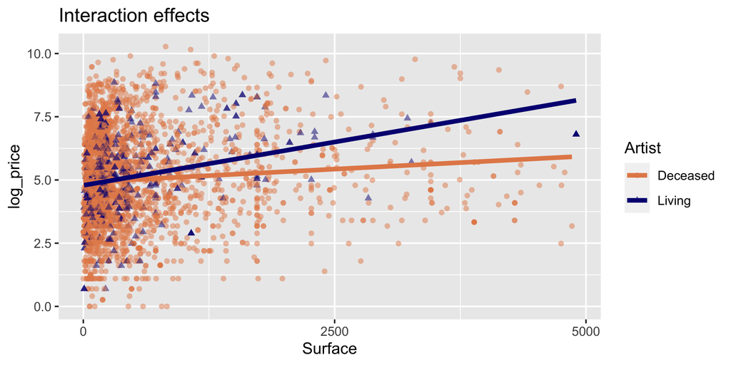

# Comparing models

## R-squared

- $R^2$ is the percentage of variability in the response variable explained by the regression model.

```r
glance(pp_main_fit)$r.squared
```

```
[1] 0.01320884
```

```r
glance(pp_int_fit)$r.squared
```

```
[1] 0.0176922
```

- Clearly the model with interactions has a higher $R^2$.
- However using $R^2$ for model selection in models with multiple explanatory variables is not a good idea as $R^2$ increases when **any** variable is added to the model.

## Adjusted R-squared

It appears that adding the interaction actually increased adjusted $R^2$, so we should indeed use the model with the interactions.

```r
glance(pp_main_fit)$adj.r.squared
```

```
[1] 0.01258977
```

```r
glance(pp_int_fit)$adj.r.squared
```

```
[1] 0.01676753
```

## Third order interactions

- Can you? Yes
- Should you? Probably not if you want to interpret these interactions in context of the data.

## In pursuit of Occam’s razor

- Occam’s Razor states that among competing hypotheses that predict equally well, the one with the fewest assumptions should be selected.
- Model selection follows this principle.
- We only want to add another variable to the model if the addition of that variable brings something valuable in terms of predictive power to the model.
- In other words, we prefer the simplest best model, i.e. **parsimonious** model.

## Backward selection

For this demo, we’ll ignore interaction effects…and just model main effects to start:

```r
pp_full <-  lin_mod |>
  fit(log_price ~ Width_in + Height_in + Surface + artistliving, data=pp)

glance(pp_full)$adj.r.squared
```

```
[1] 0.02570141
```

- $R^2$ (full): 0.0257014

### Remove `artistliving`

```r
pp_noartist <- lin_mod |>
  fit(log_price ~ Width_in + Height_in + Surface, data=pp)

glance(pp_noartist)$adj.r.squared
```

```
[1] 0.02579859
```

. . .

- $R^2$ (full): 0.0257
- $R^2$ (no `artistliving`): 0.0258

…Improved variance explained

. . .

### Remove `Surface`

```r
pp_noartist_nosurface <- lin_mod |>
  fit(log_price ~ Width_in + Height_in, data=pp)

glance(pp_noartist_nosurface)$adj.r.squared
```

```
[1] 0.02231559
```

. . .

- $R^2$ (full): 0.0257
- $R^2$ (no `artistliving`): 0.0258
- $R^2$ (no `artistliving` or `Surface`): 0.0223

. . .

…no longer gaining improvement, so we stick with: `log_price ~ Width_in + Height_in + Surface`

## Other approach:

```r
# requires package installation:
# install.packages("olsrr")
library(olsrr)
```

**Step 1: Fit model (w/o `tidymodels`)**

```r
# fit the model (not using tidymodels)
mod <- lm(log_price ~ Width_in + Height_in + Surface + artistliving, data=pp_Surf_lt_5000)
```

**Step 2: Determine which variables to remove**

```r
ols_step_backward_p(mod)
```

```
                             Elimination Summary
------------------------------------------------------------------------------
        Variable                      Adj.
Step      Removed       R-Square    R-Square     C(p)        AIC         RMSE
------------------------------------------------------------------------------
   1    artistliving      0.0261      0.0251    3.8495    12603.7727    1.8315
------------------------------------------------------------------------------
```

…specifies that `artistliving` should be removed

**Step 2 (alternate): Compare all possible models…**

```r
ols_step_all_possible(mod) |>
  arrange(desc(adjr))
```

```
   Index N                              Predictors     R-Square Adj. R-Square
1     11 3              Width_in Height_in Surface 0.0260749939  0.0251349118
2     15 4 Width_in Height_in Surface artistliving 0.0263412027  0.0250876993
3      5 2                      Width_in Height_in 0.0256902566  0.0250634893
4     12 3         Width_in Height_in artistliving 0.0259732581  0.0250330779
5      6 2                        Width_in Surface 0.0249136264  0.0242863596
6     13 3           Width_in Surface artistliving 0.0251787948  0.0242378477
7      7 2                   Width_in artistliving 0.0212864021  0.0206568018
8      1 1                                Width_in 0.0209415833  0.0206267736
9      8 2                    Surface artistliving 0.0132088377  0.0125897717
10     2 1                                 Surface 0.0125899681  0.0122803381
11    14 3          Height_in Surface artistliving 0.0130836930  0.0121310711
12     9 2                       Height_in Surface 0.0126782901  0.0120431523
13    10 2                  Height_in artistliving 0.0062698155  0.0056305552
14     3 1                               Height_in 0.0058797727  0.0055601199
```

[output cut: 17 more lines]

# End of Material Covered on Midterm

## Recap

- Can you model and interpret linear models with multiple predictors?
- Can you explain the difference in a model with main effects vs. interaction effects?
- Can you compare different models and determine how to proceed?
- Can you carry out and explain backward selection?

[figure not shown]

https://cogs137.github.io/website/